# Dietary Data Survey Analysis

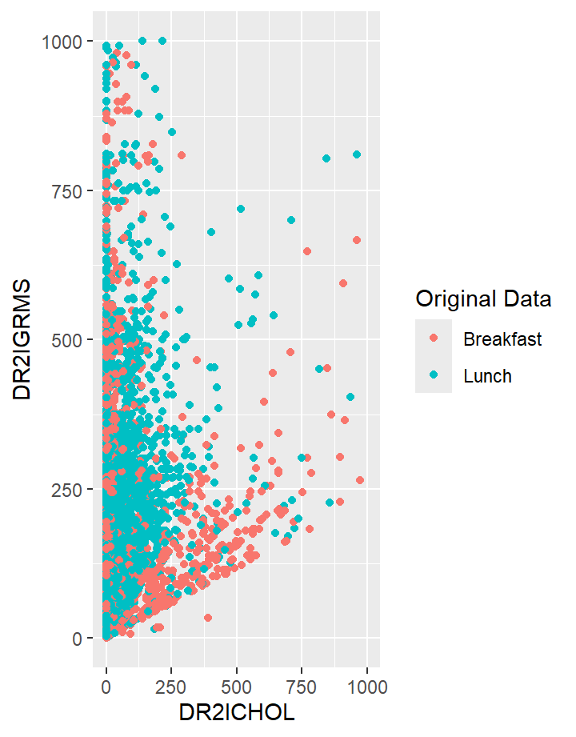

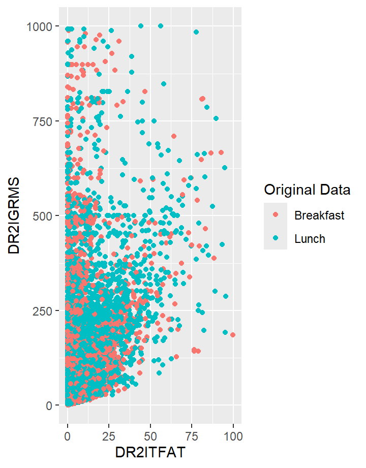

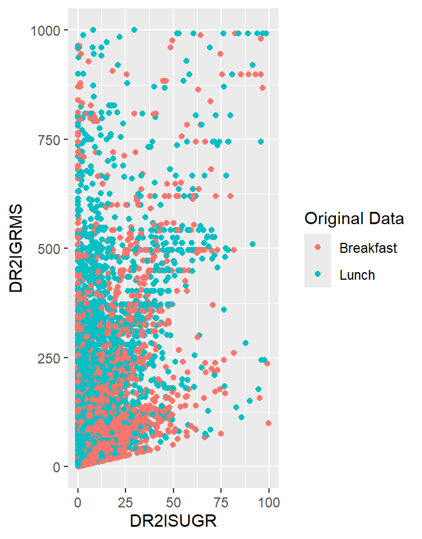

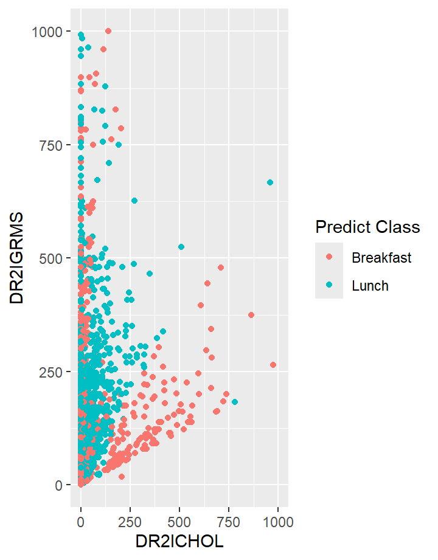

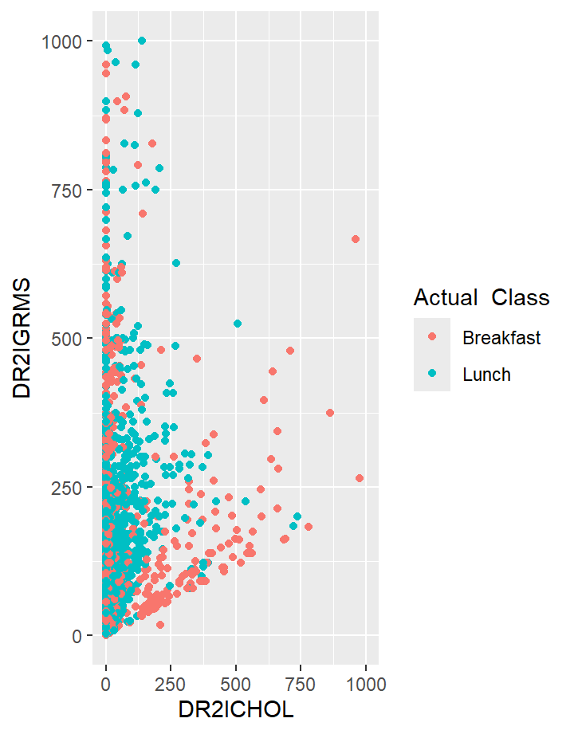

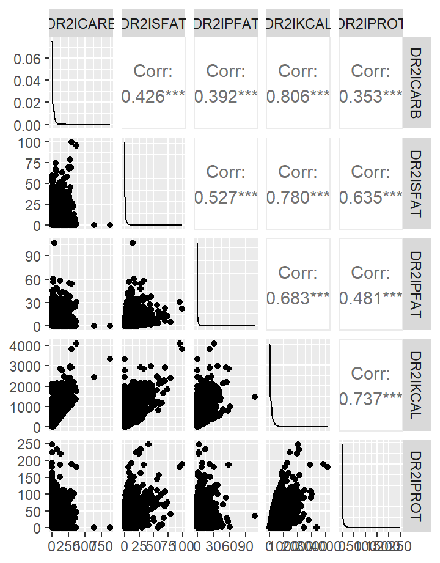

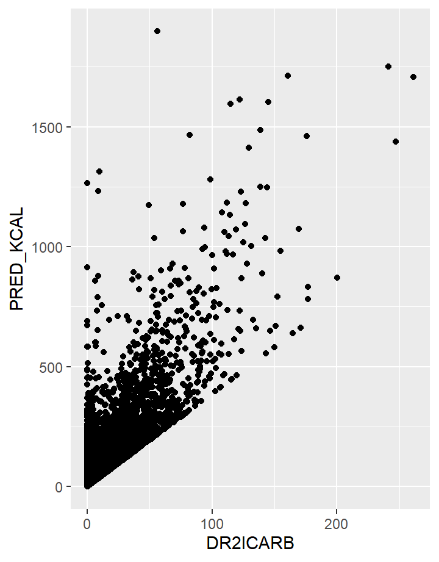

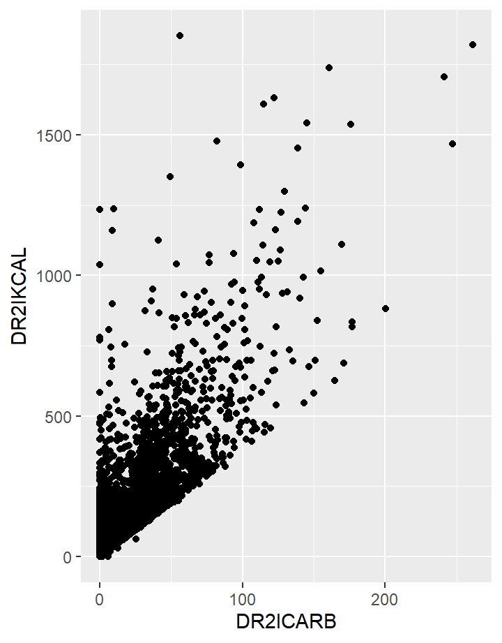

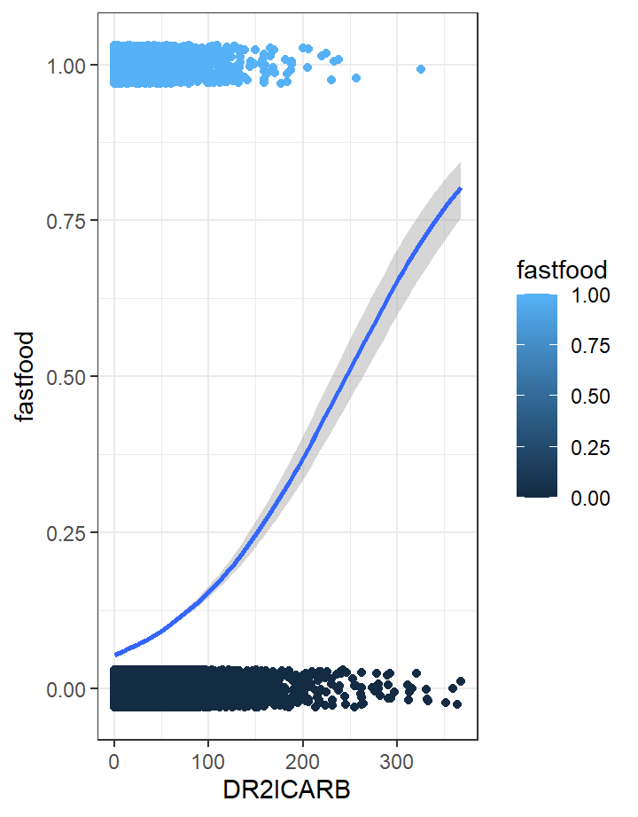

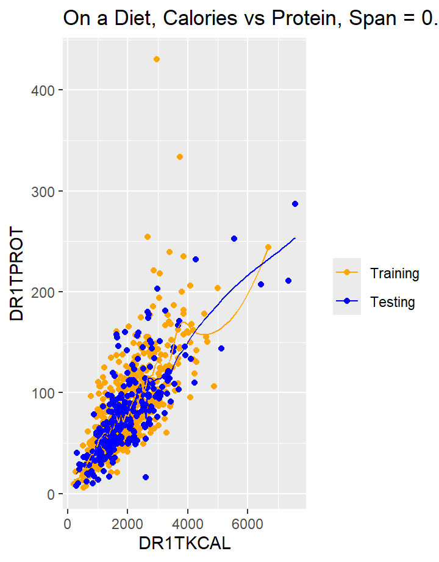

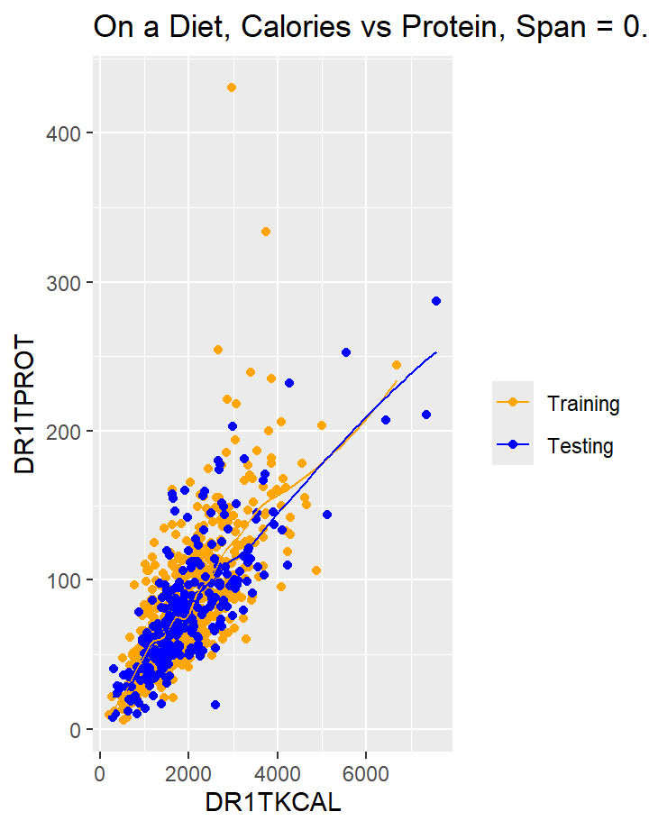

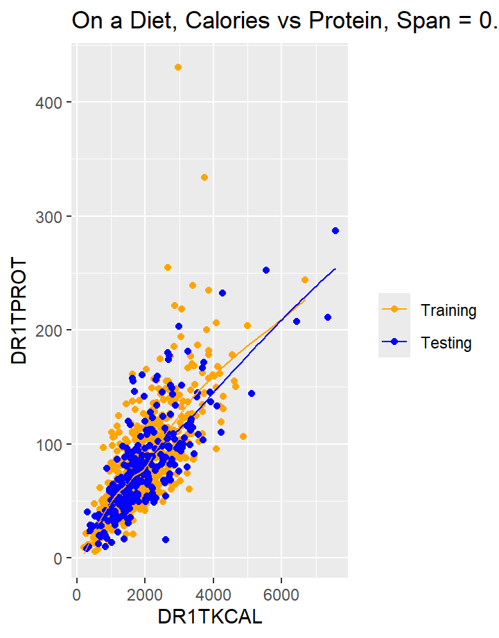

[5 more figures not shown]

# Abstract

The following data analysis studies the dietary intake information from a 2015-2016 Dietary Data survey by the CDC. The following data techniques are used to explore various relationships between nutritional information and dietary consumption patterns.

kNN

Multiple Regression

Logistic Regression

Naive Bayes

LOESS Fit

Natural Cubic Spline

kNN is used to differentiate between breakfast and lunch via various nutritional values. Multiple Regression was used to determine whether the amount of calories in food is correlated to the amount of carbs, fats, and proteins in the food. Logistic regression was used to predict whether a food was from a fastfood place according to its nutritional values. Naive Bayes was used to classify whether a food was eaten at breakfast, lunch, or dinner based on its calorie count. A LOESS fit was used to model the protein intake of people on diets. Finally, a Natural Cubic Spline was used to analyze how the caloric value of consumed foods changes throughout the day. The results of these studies can be viewed in the appropriately marked tabs.

# Introduction

### Data Set Background

This data set comes from the CDC and is the 2015-2016 Dietary Data from the National Heath and Nutrition Examination Survey. A link to the data source is found below:

https://wwwn.cdc.gov/nchs/nhanes/search/datapage.aspx?Component=Dietary&CycleBeginYear=2015

The purpose of this data set was to interview and record the dietary intake information from participants in the National Heath and Nutrition Examination Survey. People were interviewed twice about their dietary intake in the previous 24 hours. The first interview was conducted in person and the second was conducted via telephone 3 to 10 days later.

There were multiple data sets archived in this source, but this study only uses the Individual Foods and Total Nutrient Intakes data sets for analysis. The variables in each of these data sets are described in the following data dictionary.

Overall, the goal the this analysis is to look at food consumption habits of the people in this survey, including what they ate at certain meals or the relationships between various nutrients consumed throughout the day.

### Data Dictionary

**From the DR2IFF_I data set:

SEQN - Respondent sequence number

WTDRD1 - Dietary day one sample weight

WTDR2D - Dietary two-day sample weight

DR2ILINE - Food/Individual component number

DR2DRSTZ - Dietary recall status

DR2EXMER - Interviewer ID code

DRABF - Breast-fed infant (either day)

DRDINT - Number of days of intake

DR2DBIH - # of days b/w intake and HH interview

DR2DAY - Intake day of the week

DR2LANG - Language respondent used mostly

DR2CCMNM - Combination food number

DR2CCMTX - Combination food type

DR2_020 - Time of eating occasion (HH:MM)

DR2_030Z - Name of eating occasion

DR2FS - Source of food

DR2_040Z - Did you eat this meal at home?

DR2IFDCD - USDA food code

DR2IGRMS - Grams

DR2IKCAL - Energy (kcal)

DR2IPROT - Protein (gm)

DR2ICARB - Carbohydrate (gm)

DR2ISUGR - Total sugars (gm)

DR2IFIBE - Dietary fiber (gm)

DR2ITFAT - Total fat (gm)

DR2ISFAT - Total saturated fatty acids (gm)

DR2IMFAT - Total monounsaturated fatty acids (gm)

DR2IPFAT - Total polyunsaturated fatty acids (gm)

DR2ICHOL - Cholesterol (mg)

DR2IATOC - Vitamin E as alpha-tocopherol (mg)

DR2IATOA - Added alpha-tocopherol (Vitamin E) (mg)

DR2IRET - Retinol (mcg)

DR2IVARA - Vitamin A, RAE (mcg)

DR2IACAR - Alpha-carotene (mcg)

DR2IBCAR - Beta-carotene (mcg)

DR2ICRYP - Beta-cryptoxanthin (mcg)

DR2ILYCO - Lycopene (mcg)

DR2ILZ - Lutein + zeaxanthin (mcg)

DR2IVB1 - Thiamin (Vitamin B1) (mg)

DR2IVB2 - Riboflavin (Vitamin B2) (mg)

DR2INIAC - Niacin (mg)

DR2IVB6 - Vitamin B6 (mg)

DR2IFOLA - Total folate (mcg)

DR2IFA - Folic acid (mcg)

DR2IFF - Food folate (mcg)

DR2IFDFE - Folate, DFE (mcg)

DR2ICHL - Total choline (mg)

DR2IVB12 - Vitamin B12 (mcg)

DR2IB12A - Added vitamin B12 (mcg)

DR2IVC - Vitamin C (mg)

DR2IVD - Vitamin D (D2 + D3) (mcg)

DR2IVK - Vitamin K (mcg)

DR2ICALC - Calcium (mg)

DR2IPHOS - Phosphorus (mg)

DR2IMAGN - Magnesium (mg)

DR2IIRON - Iron (mg)

DR2IZINC - Zinc (mg)

DR2ICOPP - Copper (mg)

DR2ISODI - Sodium (mg)

DR2IPOTA - Potassium (mg)

DR2ISELE - Selenium (mcg)

DR2ICAFF - Caffeine (mg)

DR2ITHEO - Theobromine (mg)

DR2IALCO - Alcohol (gm)

DR2IMOIS - Moisture (gm)

DR2IS040 - SFA 4:0 (Butanoic) (gm)

DR2IS060 - SFA 6:0 (Hexanoic) (gm)

DR2IS080 - SFA 8:0 (Octanoic) (gm)

DR2IS100 - SFA 10:0 (Decanoic) (gm)

DR2IS120 - SFA 12:0 (Dodecanoic) (gm)

DR2IS140 - SFA 14:0 (Tetradecanoic) (gm)

DR2IS160 - SFA 16:0 (Hexadecanoic) (gm)

DR2IS180 - SFA 18:0 (Octadecanoic) (gm)

DR2IM161 - MFA 16:1 (Hexadecenoic) (gm)

DR2IM181 - MFA 18:1 (Octadecenoic) (gm)

DR2IM201 - MFA 20:1 (Eicosenoic) (gm)

DR2IM221 - MFA 22:1 (Docosenoic) (gm)

DR2IP182 - PFA 18:2 (Octadecadienoic) (gm)

DR2IP183 - PFA 18:3 (Octadecatrienoic) (gm)

DR2IP184 - PFA 18:4 (Octadecatetraenoic) (gm)

DR2IP204 - PFA 20:4 (Eicosatetraenoic) (gm)

DR2IP205 - PFA 20:5 (Eicosapentaenoic) (gm)

DR2IP225 - PFA 22:5 (Docosapentaenoic) (gm)

DR2IP226 - PFA 22:6 (Docosahexaenoic) (gm)

**From the DR1TOT_I data set

SEQN - Respondent sequence number

WTDRD1 - Dietary day one sample weight

WTDR2D - Dietary two-day sample weight

DR1DRSTZ - Dietary recall status

DR1EXMER - Interviewer ID code

DRABF - Breast-fed infant (either day)

DRDINT - Number of days of intake

DR1DBIH - # of days b/w intake and HH interview

DR1DAY - Intake day of the week

DR1LANG - Language respondent used mostly

DR1MRESP - Main respondent for this interview

DR1HELP - Helped in responding for this interview

DBQ095Z - Type of table salt used

DBD100 - How often add salt to food at table

DRQSPREP - Salt used in preparation?

DR1STY - Salt used at table yesterday?

DR1SKY - Type of salt used yesterday

DRQSDIET - On special diet?

DRQSDT1 - Weight loss/Low calorie diet

DRQSDT2 - Low fat/Low cholesterol diet

DRQSDT3 - Low salt/Low sodium diet

DRQSDT4 - Sugar free/Low sugar diet

DRQSDT5 - Low fiber diet

DRQSDT6 - High fiber diet

DRQSDT7 - Diabetic diet

DRQSDT8 - Weight gain/Muscle building diet

DRQSDT9 - Low carbohydrate diet

DRQSDT10 - High protein diet

DRQSDT11 - Gluten-free/Celiac diet

DRQSDT12 - Renal/Kidney diet

DRQSDT91 - Other special diet

DR1TNUMF - Number of foods/beverages reported

DR1TKCAL - Energy (kcal)

DR1TPROT - Protein (gm)

DR1TCARB - Carbohydrate (gm)

DR1TSUGR - Total sugars (gm)

DR1TFIBE - Dietary fiber (gm)

DR1TTFAT - Total fat (gm)

DR1TSFAT - Total saturated fatty acids (gm)

DR1TMFAT - Total monounsaturated fatty acids (gm)

DR1TPFAT - Total polyunsaturated fatty acids (gm)

DR1TCHOL - Cholesterol (mg)

DR1TATOC - Vitamin E as alpha-tocopherol (mg)

DR1TATOA - Added alpha-tocopherol (Vitamin E) (mg)

DR1TRET - Retinol (mcg)

DR1TVARA - Vitamin A, RAE (mcg)

DR1TACAR - Alpha-carotene (mcg)

DR1TBCAR - Beta-carotene (mcg)

DR1TCRYP - Beta-cryptoxanthin (mcg)

DR1TLYCO - Lycopene (mcg)

DR1TLZ - Lutein + zeaxanthin (mcg)

DR1TVB1 - Thiamin (Vitamin B1) (mg)

DR1TVB2 - Riboflavin (Vitamin B2) (mg)

DR1TNIAC - Niacin (mg)

DR1TVB6 - Vitamin B6 (mg)

DR1TFOLA - Total folate (mcg)

DR1TFA - Folic acid (mcg)

DR1TFF - Food folate (mcg)

DR1TFDFE - Folate, DFE (mcg)

DR1TCHL - Total choline (mg)

DR1TVB12 - Vitamin B12 (mcg)

DR1TB12A - Added vitamin B12 (mcg)

DR1TVC - Vitamin C (mg)

DR1TVD - Vitamin D (D2 + D3) (mcg)

DR1TVK - Vitamin K (mcg)

DR1TCALC - Calcium (mg)

DR1TPHOS - Phosphorus (mg)

DR1TMAGN - Magnesium (mg)

DR1TIRON - Iron (mg)

DR1TZINC - Zinc (mg)

DR1TCOPP - Copper (mg)

DR1TSODI - Sodium (mg)

DR1TPOTA - Potassium (mg)

DR1TSELE - Selenium (mcg)

DR1TCAFF - Caffeine (mg)

DR1TTHEO - Theobromine (mg)

DR1TALCO - Alcohol (gm)

DR1TMOIS - Moisture (gm)

DR1TS040 - SFA 4:0 (Butanoic) (gm)

DR1TS060 - SFA 6:0 (Hexanoic) (gm)

DR1TS080 - SFA 8:0 (Octanoic) (gm)

DR1TS100 - SFA 10:0 (Decanoic) (gm)

DR1TS120 - SFA 12:0 (Dodecanoic) (gm)

DR1TS140 - SFA 14:0 (Tetradecanoic) (gm)

DR1TS160 - SFA 16:0 (Hexadecanoic) (gm)

DR1TS180 - SFA 18:0 (Octadecanoic) (gm)

DR1TM161 - MFA 16:1 (Hexadecenoic) (gm)

DR1TM181 - MFA 18:1 (Octadecenoic) (gm)

DR1TM201 - MFA 20:1 (Eicosenoic) (gm)

DR1TM221 - MFA 22:1 (Docosenoic) (gm)

DR1TP182 - PFA 18:2 (Octadecadienoic) (gm)

DR1TP183 - PFA 18:3 (Octadecatrienoic) (gm)

DR1TP184 - PFA 18:4 (Octadecatetraenoic) (gm)

DR1TP204 - PFA 20:4 (Eicosatetraenoic) (gm)

DR1TP205 - PFA 20:5 (Eicosapentaenoic) (gm)

DR1TP225 - PFA 22:5 (Docosapentaenoic) (gm)

DR1TP226 - PFA 22:6 (Docosahexaenoic) (gm)

DR1_300 - Compare food consumed yesterday to usual

DR1_320Z - Total plain water drank yesterday (gm)

DR1_330Z - Total tap water drank yesterday (gm)

DR1BWATZ - Total bottled water drank yesterday (gm)

DR1TWS - Tap water source

DRD340 - Shellfish eaten during past 30 days

DRD350A - Clams eaten during past 30 days

DRD350AQ - # of times clams eaten in past 30 days

DRD350B - Crabs eaten during past 30 days

DRD350BQ - # of times crabs eaten in past 30 days

DRD350C - Crayfish eaten during past 30 days

DRD350CQ - # of times crayfish eaten past 30 days

DRD350D - Lobsters eaten during past 30 days

DRD350DQ - # of times lobsters eaten past 30 days

DRD350E - Mussels eaten during past 30 days

DRD350EQ - # of times mussels eaten in past 30 days

DRD350F - Oysters eaten during past 30 days

DRD350FQ - # of times oysters eaten in past 30 days

DRD350G - Scallops eaten during past 30 days

DRD350GQ - # of times scallops eaten past 30 days

DRD350H - Shrimp eaten during past 30 days

DRD350HQ - # of times shrimp eaten in past 30 days

DRD350I - Other shellfish eaten past 30 days

DRD350IQ - # of times other shellfish eaten

DRD350J - Other unknown shellfish eaten past 30 days

DRD350JQ - # of times other unknown shellfish eaten

DRD350K - Refused on shellfish eaten past 30 days

DRD360 - Fish eaten during past 30 days

DRD370A - Breaded fish products eaten past 30 days

DRD370AQ - # of times breaded fish products eaten

DRD370B - Tuna eaten during past 30 days

DRD370BQ - # of times tuna eaten in past 30 days

DRD370C - Bass eaten during past 30 days

DRD370CQ - # of times bass eaten in past 30 days

DRD370D - Catfish eaten during past 30 days

DRD370DQ - # of times catfish eaten in past 30 days

DRD370E - Cod eaten during past 30 days

DRD370EQ - # of times cod eaten in past 30 days

DRD370F - Flatfish eaten during past 30 days

DRD370FQ - # of times flatfish eaten past 30 days

DRD370G - Haddock eaten during past 30 days

DRD370GQ - # of times haddock eaten in past 30 days

DRD370H - Mackerel eaten during past 30 days

DRD370HQ - # of times mackerel eaten past 30 days

DRD370I - Perch eaten during past 30 days

DRD370IQ - # of times perch eaten in past 30 days

DRD370J - Pike eaten during past 30 days

DRD370JQ - # of times pike eaten in past 30 days

DRD370K - Pollock eaten during past 30 days

DRD370KQ - # of times pollock eaten in past 30 days

DRD370L - Porgy eaten during past 30 days

DRD370LQ - # of times porgy eaten in past 30 days

DRD370M - Salmon eaten during past 30 days

DRD370MQ - # of times salmon eaten in past 30 days

DRD370N - Sardines eaten during past 30 days

DRD370NQ - # of times sardines eaten past 30 days

DRD370O - Sea bass eaten during past 30 days

DRD370OQ - # of times sea bass eaten past 30 days

DRD370P - Shark eaten during past 30 days

DRD370PQ - # of times shark eaten in past 30 days

DRD370Q - Swordfish eaten during past 30 days

DRD370QQ - # of times swordfish eaten past 30 days

DRD370R - Trout eaten during past 30 days

DRD370RQ - # of times trout eaten in past 30 days

DRD370S - Walleye eaten during past 30 days

DRD370SQ - # of times walleye eaten in past 30 days

DRD370T - Other fish eaten during past 30 days

DRD370TQ - # of times other fish eaten past 30 days

DRD370U - Other unknown fish eaten in past 30 days

DRD370UQ - # of times other unknown fish eaten

DRD370V - Refused on fish eaten past 30 days

# KNN Model

### Background & Write-up

The research question that we proposed for building the k-nearest neighbors (kNN) classification model, is the following question:

“Is it possible to determine whether a person is consuming their meal at breakfast or lunch based on the caloric and nutrition values of that meal alone?”

In order to explore this we first did some preliminary research online to identify nutrition categories or values that we can use to potentially differentiate breakfast from lunch. Thereafter we confirmed if these metrics were discernable in the dataset by determining if we could visually identify distinct clusters for breakfast and lunch foods for certain nutrition metrics. We identified that cholesterol, sugar, and amount of grams were classes that could be used to differentiate the two.

Compared to breakfast foods, lunch foods are known to include bigger portions, have a higher portion of cholesterol, and a lower amount of sugar. The citations/research that we used to justify these claims are reproduced below.

Lunch foods are typically more composed “unhealthy fats” that include processed or deli-style meats, processed foods, and takeaway foods. All of these types of foods are related to high amounts of cholesterol. This difference between breakfast foods and lunch foods makes it an ideal metric to differentiate whether a food was consumed during breakfast or lunch.

https://www.betterhealth.vic.gov.au/health/conditionsandtreatments/cholesterol-healthy-eating-tips

Typically breakfast meals are low in calories when contrasted with lunch meals. Breakfast meals typically are 300-400 calories while lunch can be anywhere between 500-700 calories. This difference in calories can be related to the grams of the meal itself. The more calories the heavier the food would have to be. Therefore one of the classes we chose to differentiate breakfast and lunch was the amount of grams of the food that was consumed (DR2IGRMS).

https://globalnews.ca/news/3615212/this-is-what-your-breakfast-lunch-and-dinner-calories-actually-look-like/

For the last class we chose sugars as another indicator of whether a food was consumed during breakfast or lunch. As reported by Harvard School of Public Health, added sugars are high in breakfast cereals. With this in mind, we speculated that the total sugar content within the food consumed would be a reasonable indicator for whether a meal was eaten during breakfast or for lunch. The higher the amount of sugars, proportional to the same amount of weight, was related to breakfast foods while the inverse was related to lunch foods. We explored the data and did find this to be partially true. Breakfast foods showed a slight difference in lunch foods when indexed for sugar (DR2ISUGR).

https://nutritionsource.hsph.harvard.edu/carbohydrates/added-sugar-in-the-diet/

### Data Exploration: Cholesterol

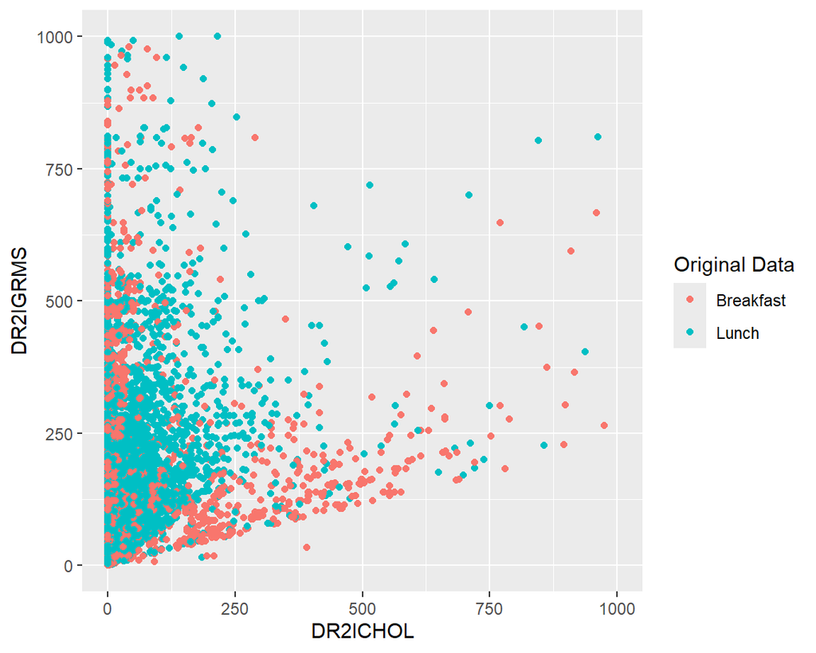

### Data Exploration: Total Fat

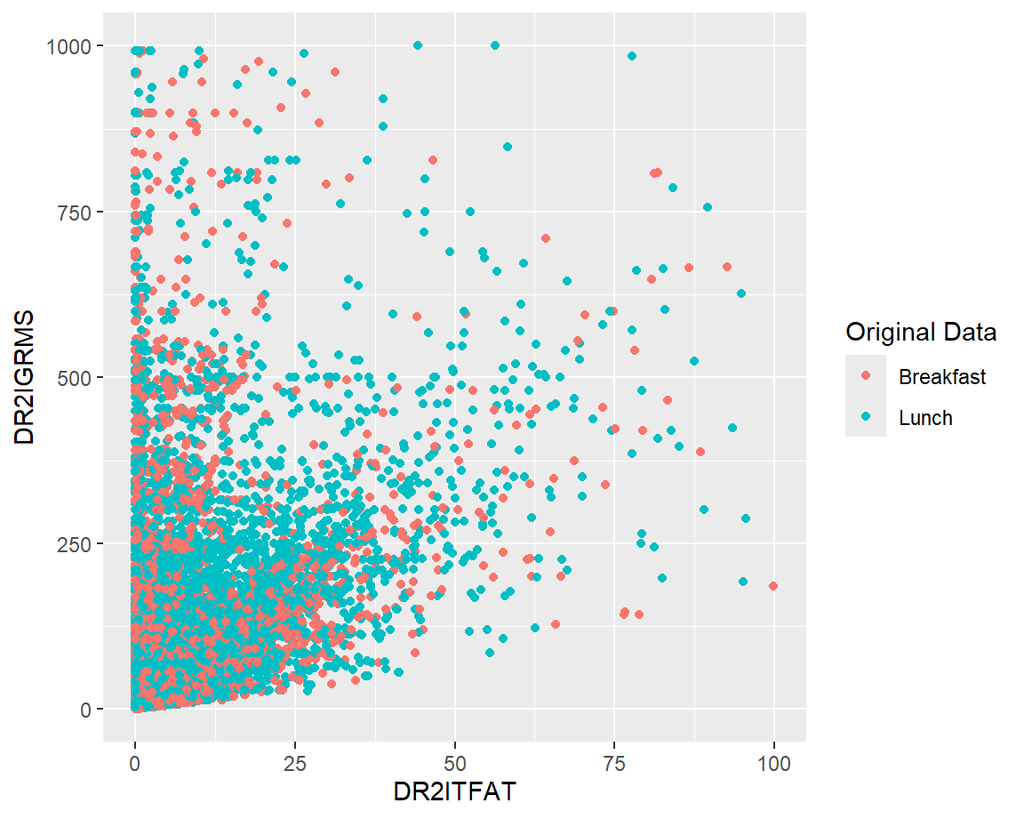

### Data Exploration: Sugar

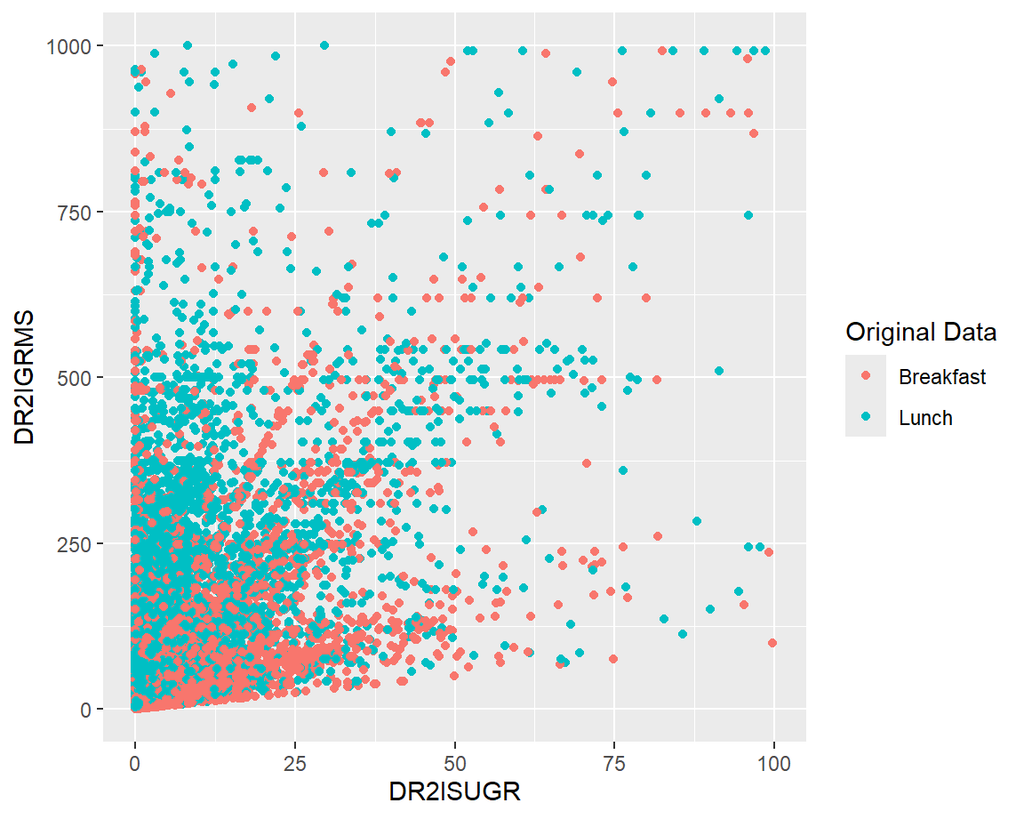

### Building the Model

Once confirming there were visible differences between all three classes for breakfast and lunch we then continued to build a k-nearest neighbors model to predict whether a food was consumed breakfast or lunch based on sugar content, grams of food, amount of fat, and amount of cholesterol.

We trained the model and we got the results below. The plot is for only 20% of the original data (the test set) and it shows whether it classified the food as consumed during breakfast or lunch.

### Building the Model

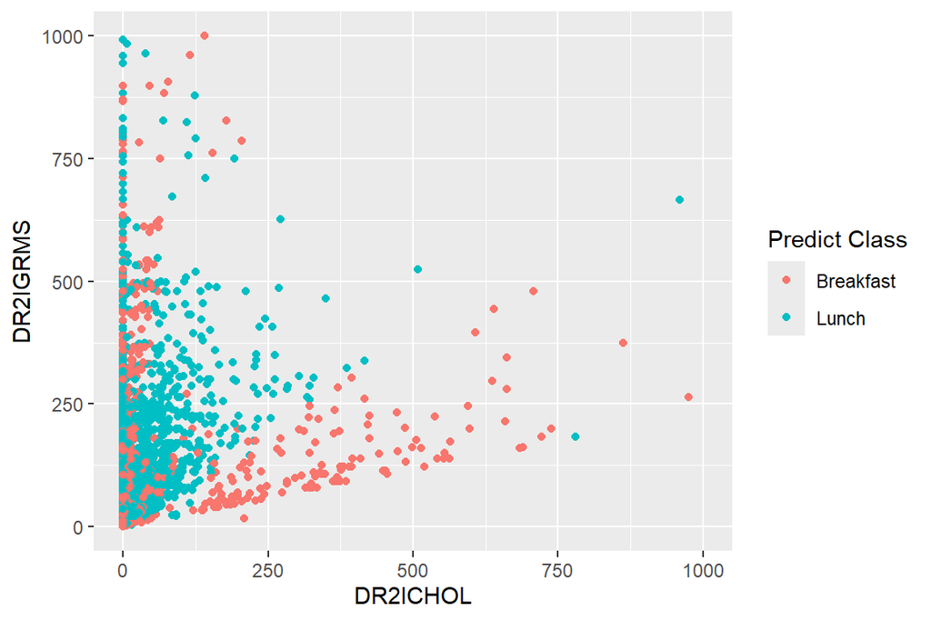

### Chart 1

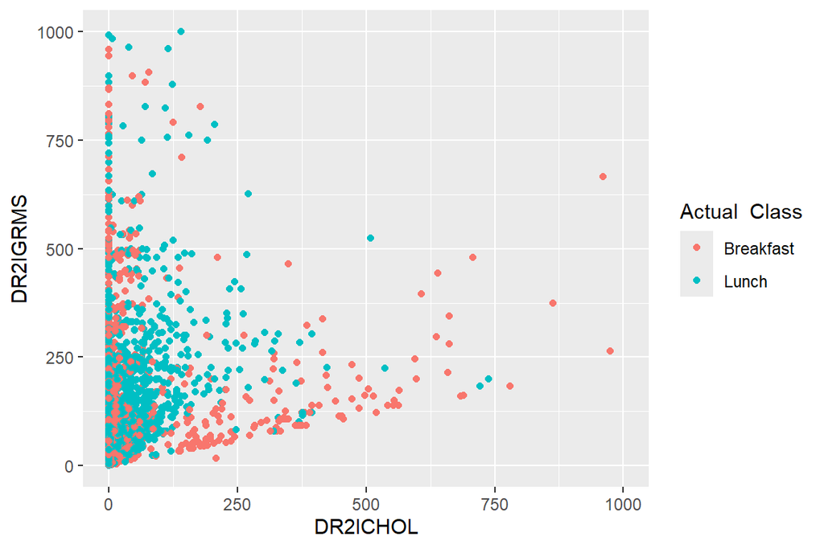

### Confusion Matrix

Finally we show a confusion matrix below,

### Confusion Matrix

Confusion Matrix

| Prediction | Reference | Amount |
| --- | --- | --- |
| 1 | 1 | 2755 |
| 2 | 1 | 1066 |
| 1 | 2 | 888 |
| 2 | 2 | 3276 |

# Multiple Regression Model

### Background & Write-up

The research question we composed for the multiple regression part of the project was the following,

“Is the amount of calories within a food porportional to the amount of carbohydrates, fat, and protein within that food?” and “If so can the amount of carbohydrates, fat, and protein be used to estimate the amount of calories that food has?”

The research that relates the high amount of carbohydrates, fat, and protein to a high amount of calories is reproduced below.

https://www.webmd.com/diet/foods-high-in-carbs https://www.medicalnewstoday.com/articles/calorie-dense-food#summary https://health.clevelandclinic.org/high-calorie-snack-ideas-for-weight-gain

We thereafter decided to train a multiple regression model to see if we can reliably estimate the amount of calories a food contains given the amount of carbohydrates, fat, and protein within the food.

### Data Exploration: Correlation

To begin we determined if these classes at least correlated with the amount of calories within the food. To do that we explored the data and confirmed that all metrics had a positive correlation with calorie amount. While there is a low correlation value between the classes there is a high amount of correlation of classes relative to the kcal class.

The outcome of this data exploration is reproduced below.

### Data Exploration: Correlation

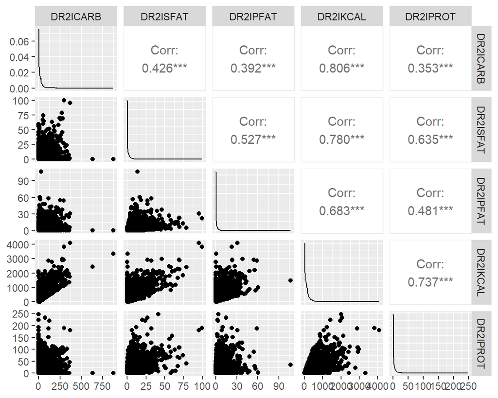

### Multiple Regression Model

We thereafter used these classes to build a multiple linear regression model. The results of the model is shown below. This is the predicted plot of the test set. We used the carbohydrates class as a placeholder for the x-axis.

### Multiple Regression Model: Predicted Values

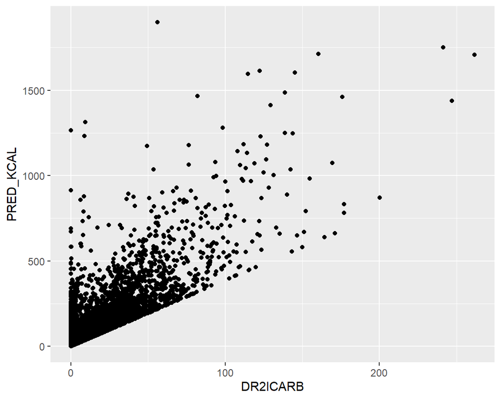

### Multiple Regression Model: Actual Values

The actual values in the model are shown below. This is the truth data that we can use to compare the predicted models in the previous plot.

### Multiple Regression Model: Actual Values

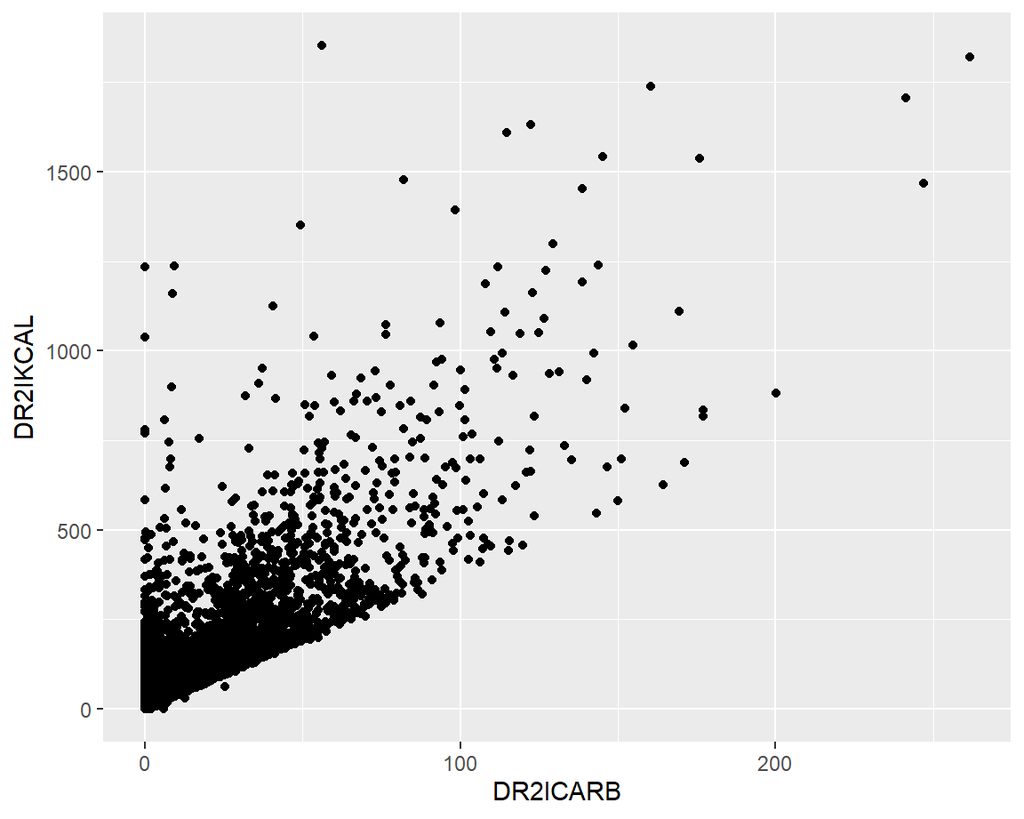

### MSE Values

Below are the MSE values for the training set and the test set.

### Calculating MSE

MSE Values

| MSE Training | MSE Test |
| --- | --- |
| 234.5133 | 203.0851 |

# Logistic Regression

### Background & Write-up

For the logistic regression model we tailored the research question to reflect the binary nature of the model. In order to do that we cleaned the data by changing the location of food class into a binary is fastfood or isn’t fastfood. With that done we posed the research question,

“Is it possible to identify whether food was eaten at a fastfood place or not depending on the calroic/nurition values associated with fastfood?”

We used similar metrics as defined by the prior research question: cholesterol, carbohydrates, and total amount of fat within the food. The citation that we can relate these metrics to unhealthy foods is reproduced below.

https://www.betterhealth.vic.gov.au/health/conditionsandtreatments/cholesterol-healthy-eating-tips

The plot below is showcasing the logistic regression model in respect the predicted values and the amount of carbohydrates within the food.

### Plots

[output not shown]

```
[1] 6224
```

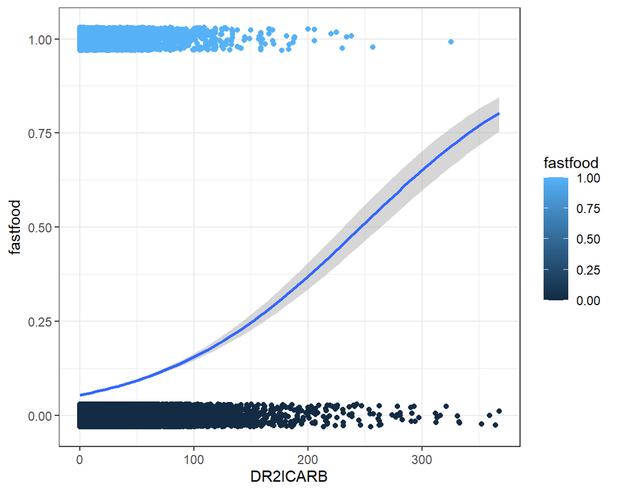

# Naive Bayes Classification

### Background & Write-up

The research question we composed for Naive Bayes Classification is the following:

“Are we able to predict whether a meal is for breakfast, lunch, or dinner based off the number of calories in the meal and at what accuracy?”

Breakfast, lunch, and dinner tend to have specific foods that are more often associated with each meal. Additionally, people tend to eat less calories at breakfast and their largest meal at dinner. The following article gives guidelines for how many calories and nutrients people should aim for in each meal of the day according to dietitions.

https://globalnews.ca/news/3615212/this-is-what-your-breakfast-lunch-and-dinner-calories-actually-look-like/#:~:text=Although%20every%20person’s%20daily%20caloric,each%20for%20lunch%20and%20dinner.

According to the article, breakfasts should be around 300 to 400 calories, lunch should be around 500 to 700 calories, and dinner should be around 600 to 700 calories. While not everyone follows these portions, it is hypothesized that there is a general trend where people eat the least for breakfast, then lunch, then the most for dinner. Using this relationship, we hope to be able to predict whether someone is eating breakfast, lunch, or dinner based off the number of calories in the meal.

### Data Exploration: Priors of Full Data Set

To begin, we isolated just the data that was associated with one of the three meals, breakfast, lunch, or dinner. Then the prior probabilities, the mean calories, and the standard deviation of the calories for each meal were calculated.

```
DR2_030Z
breakfast    dinner     lunch
0.3147272 0.3343445 0.3509284
```

```
breakfast    dinner     lunch
 111.8374  161.0874  136.6655
```

```
breakfast    dinner     lunch
 139.8298  217.2105  177.8665
```

We can see that 31% of the foods are for breakfast, 35% are for lunch, and 33% are for dinner. Breakfast foods average at 112 calories, lunch averages at 136 calories, and dinner averages at 161 calories.

### Naive Bayes Model and Confusion Matrix

```
train_classes
breakfast    dinner     lunch
0.3163999 0.3336429 0.3499571
```

```
test_classes
breakfast    dinner     lunch
0.3104751 0.3361489 0.3533759
```

|  | actual breakfast | actual dinner | actual lunch |
| --- | --- | --- | --- |
| breakfast | 4648 | 4347 | 4969 |
| dinner | 381 | 931 | 717 |
| lunch | 558 | 771 | 673 |

|  | actual breakfast | actual dinner | actual lunch |
| --- | --- | --- | --- |
| breakfast | 0.832 | 0.719 | 0.781 |
| dinner | 0.068 | 0.154 | 0.113 |
| lunch | 0.100 | 0.127 | 0.106 |

```
[1] 0.6525702
```

# Loess Fit

### Background & Write-up

For the LOESS Fit, our research question was the following:

“Do people on a diet eat foods with higher protein than people not on a diet?”

A popular diet that is stressed currently is a high protein diet. Protein is known to keep people full for longer, so less calories need to be consumed to feel full throughout the day. Protein is also good for building muscle and keeping people energized for activity throughout the day. High protein, low carb diets are very popular, so it is hypothesized that people on diets are focused on having more protein and less carbs.

### Graphing the Models

The first step is to split the data into training and testing sets at a 70:30 split. From this data, there is not a clear difference in the protein levels of the food consumed by people on a diet and people not on a diet. All graphs show that as calories increase, protein content tends to increase as well.

### Diet Plot, Span = 0.1

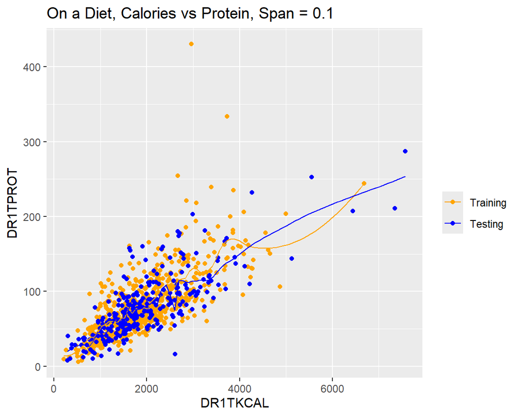

### Diet Plot, Span = 0.3

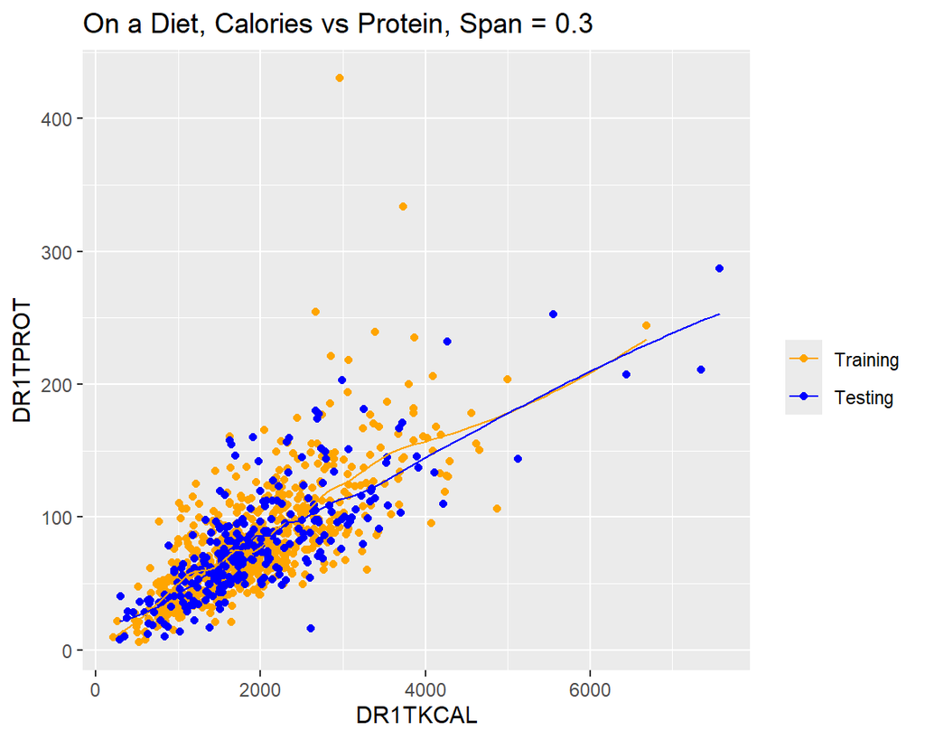

### Diet Plot, Span = 0.5

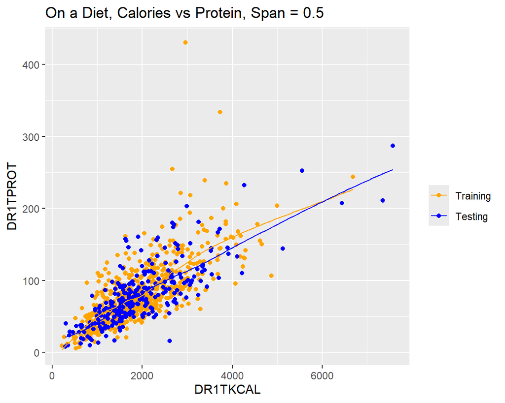

### No Diet Plot, Span = 0.1

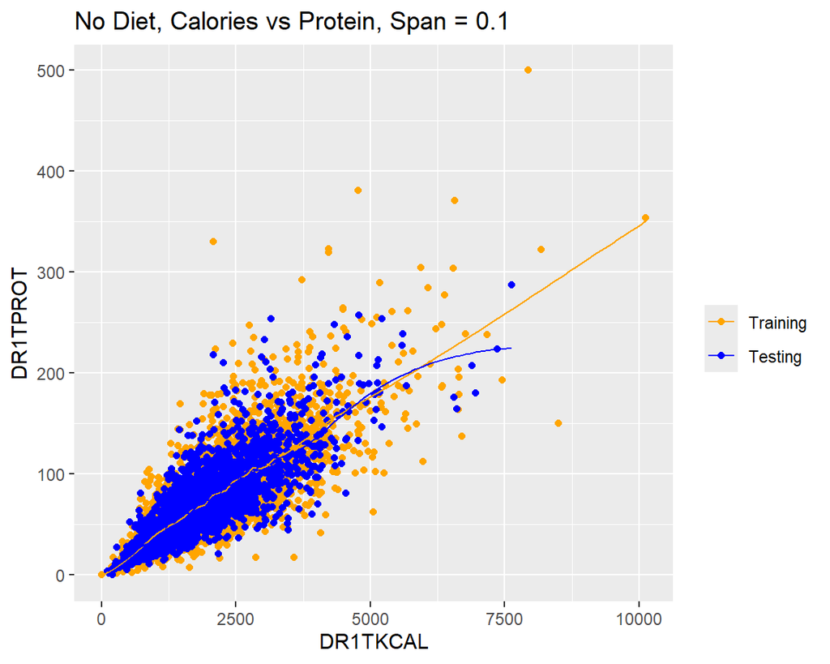

### No Diet Plot, Span = 0.3

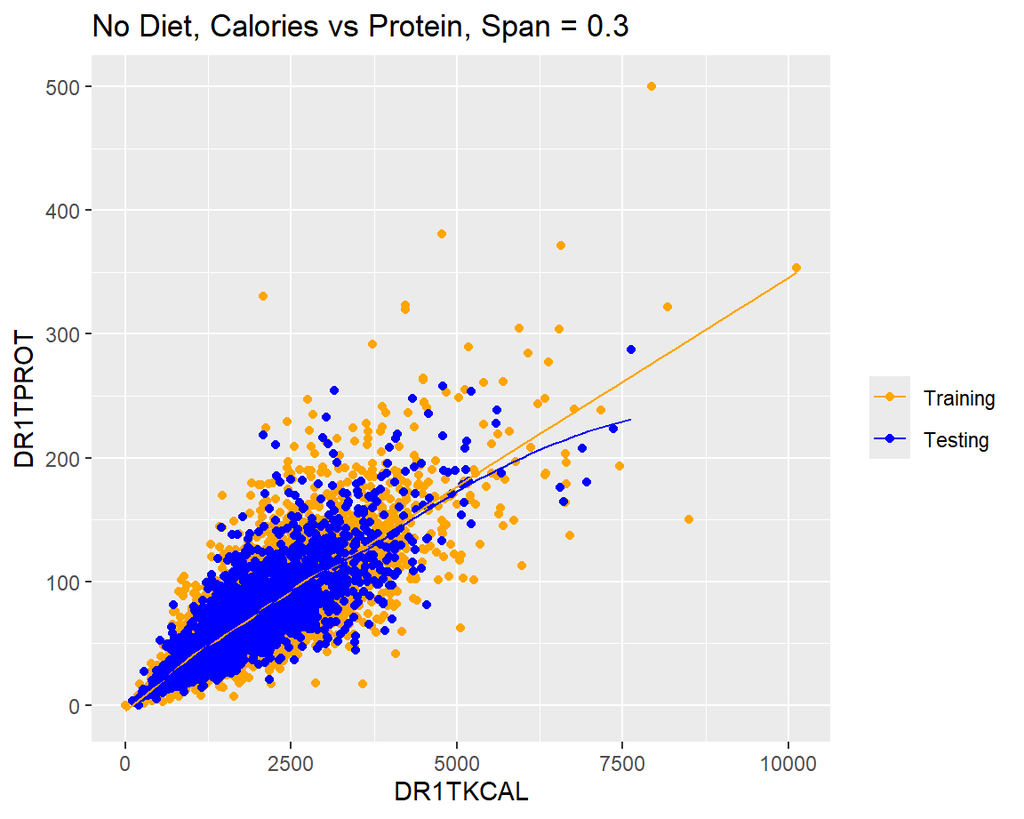

### No Diet Plot, Span = 0.5

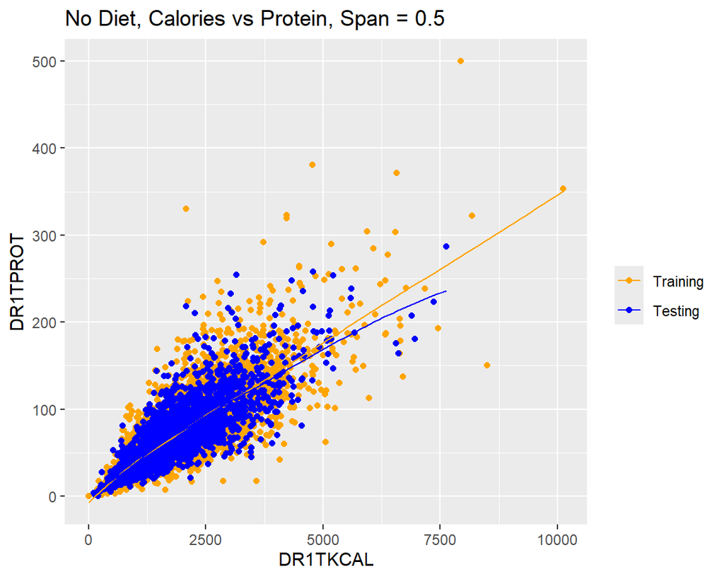

### Diet MSE

| model | MSE_Tr_diet | MSE_Te_diet |
| --- | --- | --- |
| Span = 0.1 | 7780600 | 8025487 |
| Span = 0.3 | 7779811 | 8025069 |
| Span = 0.5 | 7777005 | 8023131 |

### No Diet MSE

| model | MSE_Tr_no_diet | MSE_Te_no_diet |
| --- | --- | --- |
| Span = 0.1 | 69477597 | 66206606 |
| Span = 0.3 | 69479495 | 66208087 |
| Span = 0.5 | 69483682 | 66211219 |

# Natural Cubic Spline

### Background & Write-up

The research question for the natural cubic spline is the following:

“How does the number of calories in consumed foods change throughout the different times of the day?”

Breakfast is usually the least caloric meal of the day, and more caloric foods are likely to be eaten at dinner or in the evening for desert. Therefore, it is proposed that lower calorie foods are eaten earlier in the day, while higher calorie foods are consumed later in the day.

### Cubic Spline split in 4

```
[1] "numeric"
```

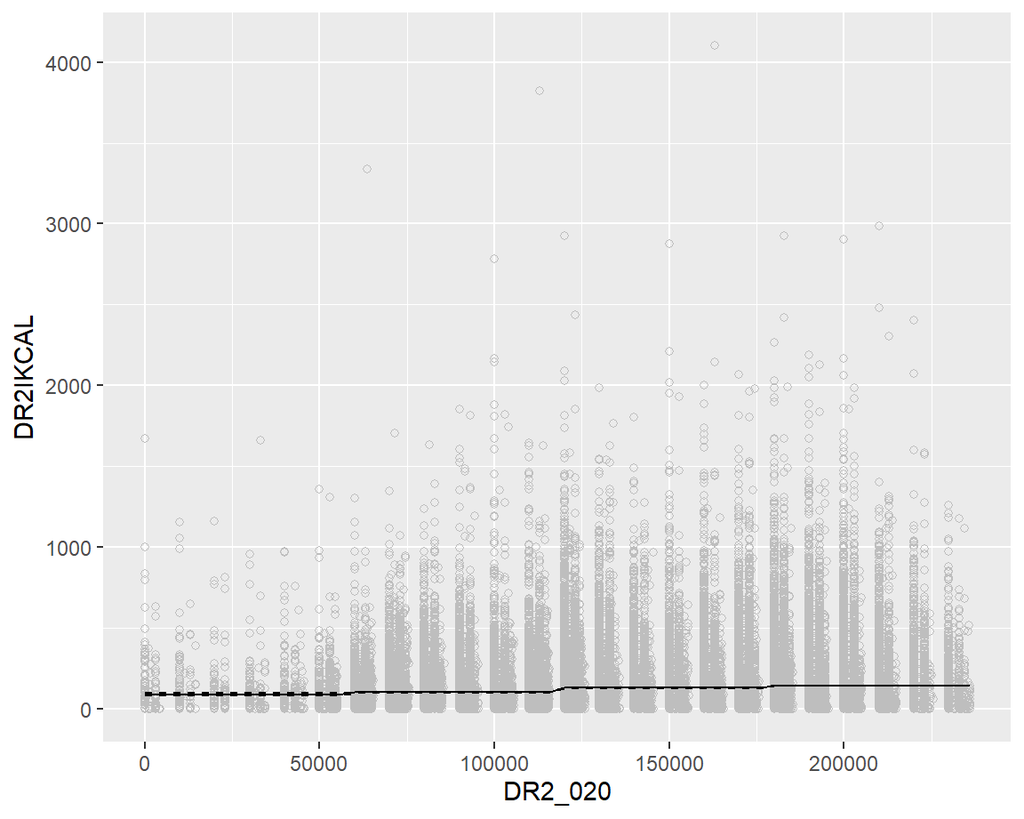

### Analysis

Above, we can see from this cubic spline that there is not much of a difference in caloric intake at different times of the day, but there is a slight increase towards later parts of the day.

Below, is the same graph, but the a cubic spline segmented at each hour. Since most of the food is concentrated in the low calorie range, there is not much evidence from the cubic spline that there is a trend of higher calorie foods being consumed later in the day. However, that does appear to be the case by looking at the raw graphical data in teh scatter plot.

### Cubic Spline split in 24

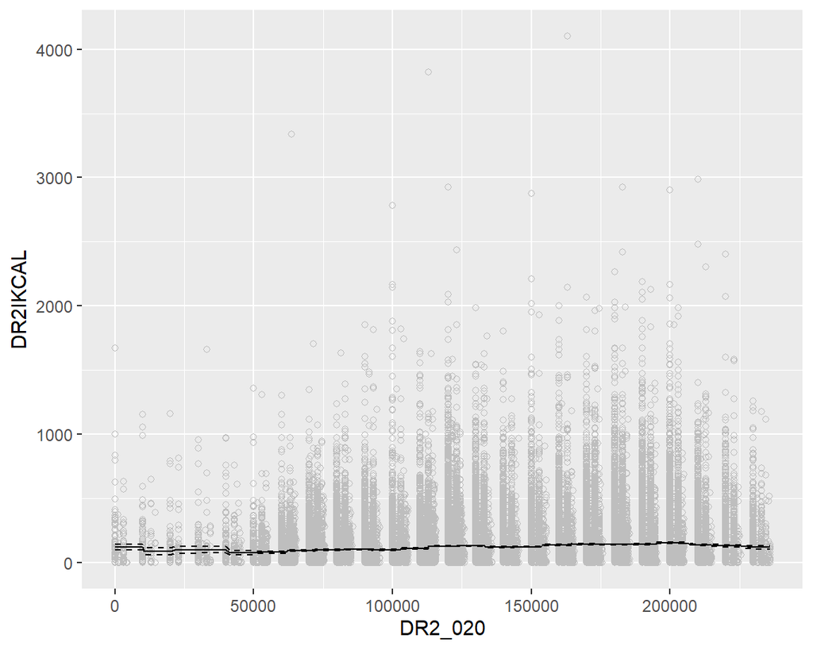